# Mile Stone Report

Juan Mari Sebastian Carino

March 9, 2019

## **Descriptive Analysis**

Before I start with my analysis, I load first the essential libraries that I would need.

```r
library(tidyverse)
library(tidytext)
library(glue)
library(data.table)
library(readr)
library(quanteda)
library(stopwords)
library(SnowballC)
library(spacyr)
```

Based on my research, these are steps in performing Natural Language Processing which I intend to follow throughout finishing the capstone project:

1. Sentence Segmentation - break the text apart into separate sentences.
2. Word Tokenization - break sentences into separate words
3. Predicting Parts of Speech for each Token
4. Text lemnatization - figure out the most basic form of each word in a sentence.
5. Identifying the stop words
6. Dependency Parsing - figure out how all the words in a sentence relate to each other.
7. Finding Noun Phrases
8. Named Entity Recognition - detect and label these nouns with the real-world concepts that they represent.
9. Conference Resolution - figure out all the words that are referring to the same entity.

I have manually downloaded the data in Coursera and thereafter, unzipped it in my computer. In loading the data, I used the readLines function and convert to a data frame. In this way, every text is stored in one row.

```r
blogs <- as_data_frame(readLines(con=file("~/Ambitions and Realities (Data Science, Career, Study Abroad)/Coursera/Data Science Specialization/Data Science Capstone/en_US.blogs.txt", open = "rt")))
colnames(blogs) <- "Blogs"

news <- as_data_frame(readLines(con=file("~/Ambitions and Realities (Data Science, Career, Study Abroad)/Coursera/Data Science Specialization/Data Science Capstone/en_US.news.txt", open = "rt")))
colnames(news) <- "News"

twitter <- as_data_frame(readLines(con=file("~/Ambitions and Realities (Data Science, Career, Study Abroad)/Coursera/Data Science Specialization/Data Science Capstone/en_US.twitter.txt", open = "rt")))
colnames(twitter) <- "Tweet"
```

The structure of our data, blogs, news, and twitter consist of one column but with many observations. The number of rows for each data is shown below:

```r
data.frame(blogs = nrow(blogs), news = nrow(news), twitter = nrow(twitter), row.names = "No. of observations")
```

```
##                      blogs  news twitter
## No. of observations 899288 77259 2360148
```

### **Corpus**

Following the NLP Process, I constructed corpus objects.

```r
blogs_corpus <- corpus(blogs$Blogs)
news_corpus <- corpus(news$News)
twitter_corpus <- corpus(twitter$Tweet)
```

### **Sampling**

Because processing the entire dataset considers a considerable huge amount of time and given that the computer can process on a certain limit number of observations, I gathered 20,000 random samples from each dataset. By taking only the samples, data analysis can be done faster and efficiently.

```r
blogs_corpus <- corpus_sample(blogs_corpus, size = 20000, replace = FALSE)
news_corpus <- corpus_sample(news_corpus, size = 20000, replace = FALSE)
twitter_corpus <- corpus_sample(twitter_corpus, size = 20000, replace = FALSE)
```

The corpus function of quanteda is smart enough to identify sentences in a given text. Using the summary function in a corpus object, R will show the text (the observation), types (the number of unique tokens in a text), tokens (the number of words), and sentences. We are going to extract the sum of types, tokens, and sentences in each dataset.

```r
blogs_summary <- summary(blogs_corpus, tolower = TRUE, n = 20000)
news_summary <- summary(news_corpus, tolower = TRUE, n = 20000)
twitter_summary <- summary(twitter_corpus, tolower = TRUE, n = 20000)

list(Blogs = colSums(blogs_summary[, 2:4]), News = colSums(news_summary[, 2:4]), Twitter = colSums(twitter_summary[, 2:4]))
```

```
## $Blogs
##     Types    Tokens Sentences
##    689772    968002     51306
##
## $News
##     Types    Tokens Sentences
##    636539    807952     39481
##
## $Twitter
##     Types    Tokens Sentences
##    277300    313269     31959
```

Based on the list, blogs dataset contains the most number of types, tokens, and sentences while twitter dataset contains the least number on these. This is true because blogs and news often contains articles which are usually composed of paragraphs and a number of non-conversational words. Twitter, on the other hand is mostly used on posting statuses and limits the number of characters (160 max.). Most of the users of Twitter write phrases and use conversational words.

### **Tokenization, Text Lemnatization, and Stopwords Removal**

I am going to look into the POS (Parts of Speech) by segmenting the sentence in the next coming weeks since I am currently encountering problems in installing and using spacyr package.

The next step in our NLP is tokenizing. In tokenizing, we are going to break sentences into words. After that, we are going to extract the stem word (e.g. the word lining = line). After that, we are going to remove noises in our text analysis which is stop words such as prepositions, punctuations, conjunctions, and other words based on the corpora.

```r
blogs_tokens <- tokens(blogs_corpus, what = "word", remove_punc = TRUE, remove_numbers = TRUE, remove_symbols = FALSE, remove_url = TRUE, remove_separators = TRUE)

news_tokens <- tokens(news_corpus, what = "word", remove_punc = TRUE, remove_numbers = TRUE, remove_symbols = FALSE, remove_url = TRUE, remove_separators = TRUE)

twitter_tokens <- tokens(twitter_corpus, what = "word", remove_punc = TRUE, remove_numbers = TRUE, remove_symbols = FALSE, remove_url = TRUE, remove_separators = TRUE)
```

Next, we are going to take the stem of the word after converting the text into lowercase.

```r
blogs_tokens <- blogs_tokens %>%
                  tokens_tolower() %>%
                  tokens_wordstem(language = "english")

news_tokens <- news_tokens %>%
                  tokens_tolower() %>%
                  tokens_wordstem(language = "english")

twitter_tokens <- twitter_tokens %>%
                  tokens_tolower() %>%
                  tokens_wordstem(language = "english")
```

Next, we are going to remove the stopwords and set the minimum character to 2 so that, words which contain only single letter will be ommitted.

```r
blogs_tokens <- blogs_tokens %>%
                  tokens_remove(stopwords(language = "en", source = "snowball"), min_nchar = 2)

news_tokens <- news_tokens %>%
                  tokens_remove(stopwords(language = "en", source = "snowball"), min_nchar = 2)

twitter_tokens <- twitter_tokens %>%
                  tokens_remove(stopwords(language = "en", source = "snowball"), min_nchar = 2)
```

Next, we are going to extract one-gram.

```r
blogs_tokens <- blogs_tokens %>%
                tokens_ngrams(n = 1, concatenator = " ")

news_tokens <- news_tokens %>%
                tokens_ngrams(n = 1, concatenator = " ")

twitter_tokens <- twitter_tokens %>%
                tokens_ngrams(n = 1, concatenator = " ")
```

## **Data Exploration**

Now that the processing is done, I am going to explore the data per dataset.

In extracting the top features, I have created a function top_n_features where the argument is dfm and number of features.

```r
top_n_features <- function(x, n){
    # x is a dfm
    # n is the number of features to extract (e.g. if top 50, then n = 50)
    features <- topfeatures(x, n) %>%
                  data.frame() %>%
                  rownames_to_column()
    colnames(features) <- c("Words", "Counts")
    as.data.frame(features)

  }
```

### **Blogs**

```r
blogs_freq <- blogs_tokens %>%
                dfm() %>%
                textstat_frequency()

summary(blogs_freq)
```

```
##    feature            frequency            rank          docfreq
##  Length:34884       Min.   :   1.00   Min.   :    1   Min.   :   1.00
##  Class :character   1st Qu.:   1.00   1st Qu.: 8722   1st Qu.:   1.00
##  Mode  :character   Median :   1.00   Median :17443   Median :   1.00
##                     Mean   :  12.22   Mean   :17443   Mean   :  10.85
##                     3rd Qu.:   4.00   3rd Qu.:26163   3rd Qu.:   3.00
##                     Max.   :2937.00   Max.   :34884   Max.   :2351.00
##     group
##  Length:34884
##  Class :character
##  Mode  :character
##
##
##
```

Here is a histogram showing the frequency of our data. It can be seen that most of the features that we have extracted occurred only a number of times indicating that the words in the blog are unique and non-repetitive.

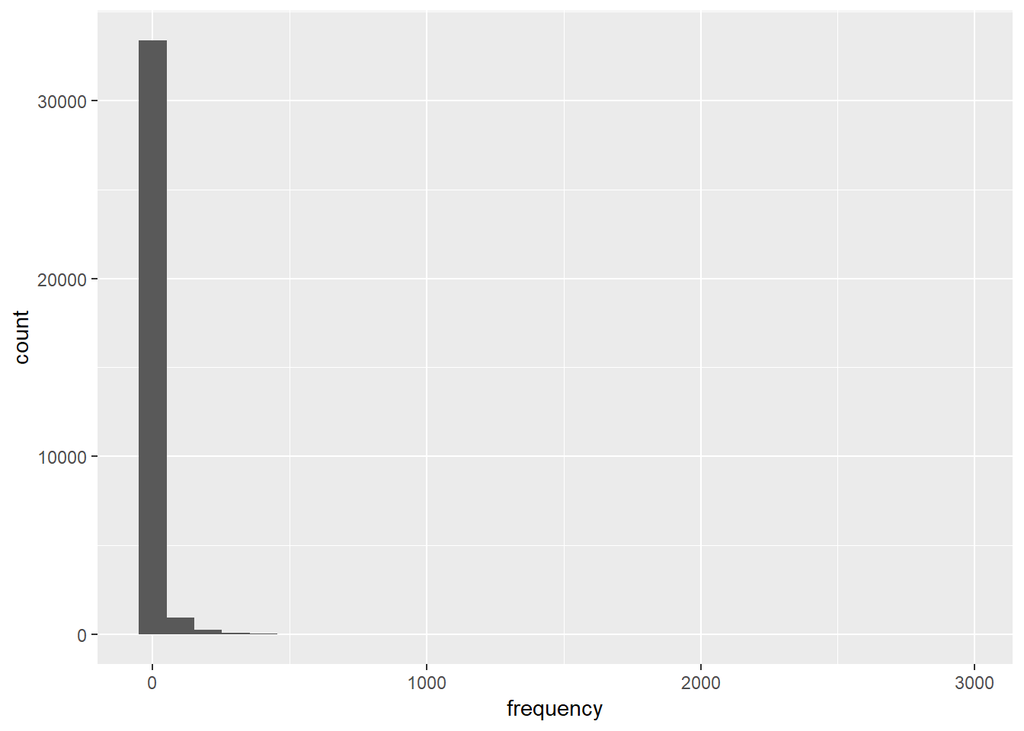

```r
ggplot(blogs_freq) + geom_histogram(aes(x = frequency))
```

Here is the top 30 features in the blog sample dataset. It can be observed that the words here are one, like, time, can, just, get, go, day, and so on. It can be inferred from these histogram that the frequent words are the subject of the blog posts and that the blog posts are usually written in active form since the author usually post blogs about his/her opinion about an issue, reports interesting topic or trends, and shares daily life things.

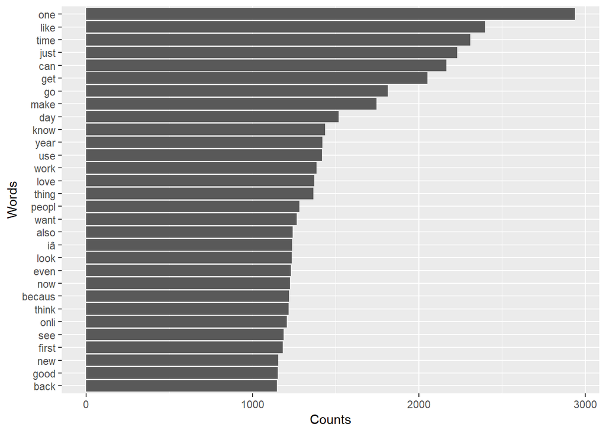

```r
top_blogs <- blogs_tokens %>%
                dfm() %>%
                top_n_features(n = 30)

ggplot(top_blogs) + geom_bar(aes(x = reorder(Words, Counts), y = Counts), stat = "identity") + xlab("Words") + coord_flip()
```

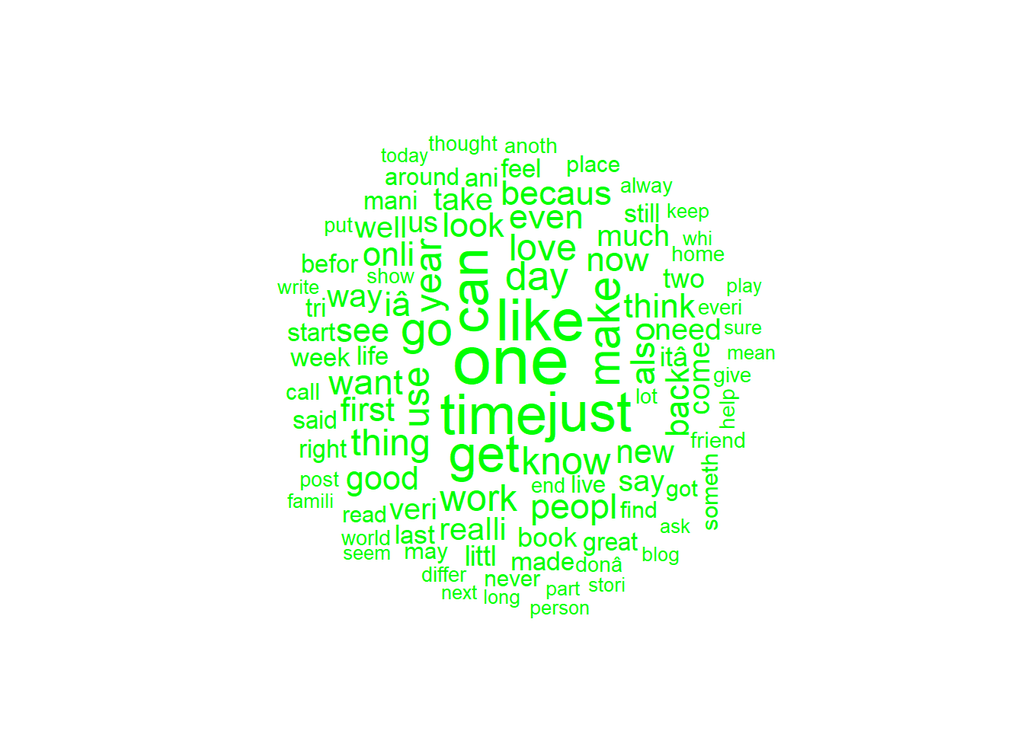

```r
blogs_dfm <- dfm(blogs_tokens)
textplot_wordcloud(blogs_dfm, max_words = 100, color = "green")
```

### **News**

```r
news_freq <- news_tokens %>%
              dfm() %>%
              textstat_frequency()

summary(news_freq)
```

```
##    feature            frequency            rank          docfreq
##  Length:33413       Min.   :   1.00   Min.   :    1   Min.   :   1.00
##  Class :character   1st Qu.:   1.00   1st Qu.: 8354   1st Qu.:   1.00
##  Mode  :character   Median :   1.00   Median :16707   Median :   1.00
##                     Mean   :  11.69   Mean   :16707   Mean   :  10.86
##                     3rd Qu.:   4.00   3rd Qu.:25060   3rd Qu.:   4.00
##                     Max.   :4982.00   Max.   :33413   Max.   :4536.00
##     group
##  Length:33413
##  Class :character
##  Mode  :character
##
##
##
```

The distribution of frequency of news sample dataset is shown below. The frequency for most of the features are 1. We can infer that most of the features/words we have extracted excluding the stopwords are non-conversational words (words which are used commonly in writing).

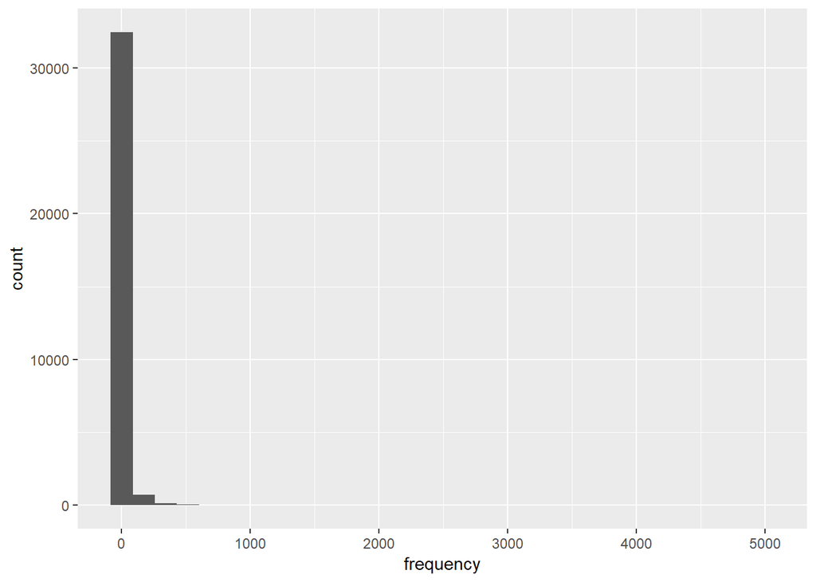

```r
ggplot(news_freq, aes(x = frequency)) + geom_histogram()
```

The top 30 words are shown below. It can be seen that the word “said” is the most frequent word. This is very obvious because news usually report statements and dialogues from key persons such as government officials and personnels, actors and actresses, and citizens. It can be seen as well the distance of counts of said to the other words. It can be inferred that these words are usually the topics or used in headlines of news such as year, new, time, state, people, work, school, and so on.

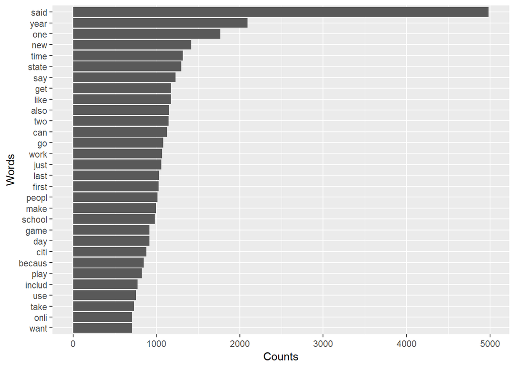

```r
top_news <- news_tokens %>%
              dfm() %>%
              top_n_features(n = 30)

ggplot(top_news) + geom_bar(aes(x = reorder(Words, Counts), y = Counts), stat = "identity") + xlab("Words") + coord_flip()
```

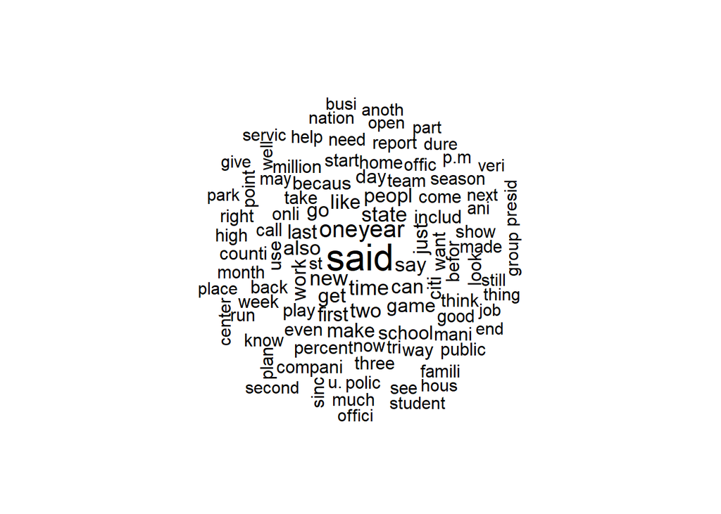

```r
news_dfm <- dfm(news_tokens)
news_wc <- textplot_wordcloud(news_dfm, min_size = 1.25, max_size = 3, max_words = 100, color = "black")
```